# Risk Factor Analysis

## Outcome Variable

**Outcome Variable:** ever_co

## Predictor Variables

**Intervention Variable:** gagebrth

**Adjustment Set:**

- arm
- sex
- W_mage
- meducyrs
- feducyrs
- hhwealth_quart
- W_nrooms
- W_nchldlt5
- brthmon
- W_parity
- impsan
- delta_W_mage
- delta_meducyrs
- delta_feducyrs
- delta_hhwealth_quart
- delta_W_nrooms
- delta_W_nchldlt5
- delta_brthmon
- delta_W_parity
- delta_impsan

## Stratifying Variables

The analysis was stratified on these variable(s):

- agecat
- studyid
- country

## Data Summary

| agecat | studyid | country | gagebrth | ever_co | n_cell | n |
| --- | --- | --- | --- | --- | --- | --- |
| 0-24 months | CMC-V-BCS-2002 | INDIA | Full or late term | 0 | 170 | 351 |
| 0-24 months | CMC-V-BCS-2002 | INDIA | Full or late term | 1 | 45 | 351 |
| 0-24 months | CMC-V-BCS-2002 | INDIA | Preterm | 0 | 35 | 351 |
| 0-24 months | CMC-V-BCS-2002 | INDIA | Preterm | 1 | 17 | 351 |
| 0-24 months | CMC-V-BCS-2002 | INDIA | Early term | 0 | 70 | 351 |
| 0-24 months | CMC-V-BCS-2002 | INDIA | Early term | 1 | 14 | 351 |
| 0-24 months | COHORTS | GUATEMALA | Full or late term | 0 | 406 | 812 |
| 0-24 months | COHORTS | GUATEMALA | Full or late term | 1 | 43 | 812 |
| 0-24 months | COHORTS | GUATEMALA | Preterm | 0 | 105 | 812 |
| 0-24 months | COHORTS | GUATEMALA | Preterm | 1 | 26 | 812 |
| 0-24 months | COHORTS | GUATEMALA | Early term | 0 | 195 | 812 |
| 0-24 months | COHORTS | GUATEMALA | Early term | 1 | 37 | 812 |
| 0-24 months | COHORTS | INDIA | Full or late term | 0 | 550 | 1371 |
| 0-24 months | COHORTS | INDIA | Full or late term | 1 | 41 | 1371 |
| 0-24 months | COHORTS | INDIA | Preterm | 0 | 280 | 1371 |
| 0-24 months | COHORTS | INDIA | Preterm | 1 | 35 | 1371 |
| 0-24 months | COHORTS | INDIA | Early term | 0 | 436 | 1371 |
| 0-24 months | COHORTS | INDIA | Early term | 1 | 29 | 1371 |
| 0-24 months | COHORTS | PHILIPPINES | Full or late term | 0 | 987 | 3019 |
| 0-24 months | COHORTS | PHILIPPINES | Full or late term | 1 | 179 | 3019 |
| 0-24 months | COHORTS | PHILIPPINES | Preterm | 0 | 502 | 3019 |
| 0-24 months | COHORTS | PHILIPPINES | Preterm | 1 | 143 | 3019 |
| 0-24 months | COHORTS | PHILIPPINES | Early term | 0 | 973 | 3019 |
| 0-24 months | COHORTS | PHILIPPINES | Early term | 1 | 235 | 3019 |
| 0-24 months | IRC | INDIA | Full or late term | 0 | 211 | 390 |
| 0-24 months | IRC | INDIA | Full or late term | 1 | 39 | 390 |
| 0-24 months | IRC | INDIA | Preterm | 0 | 28 | 390 |
| 0-24 months | IRC | INDIA | Preterm | 1 | 14 | 390 |
| 0-24 months | IRC | INDIA | Early term | 0 | 78 | 390 |
| 0-24 months | IRC | INDIA | Early term | 1 | 20 | 390 |

[output cut: 150 more lines]

The following strata were considered:

- agecat: 0-24 months, studyid: CMC-V-BCS-2002, country: INDIA
- agecat: 0-24 months, studyid: COHORTS, country: GUATEMALA
- agecat: 0-24 months, studyid: COHORTS, country: INDIA
- agecat: 0-24 months, studyid: COHORTS, country: PHILIPPINES
- agecat: 0-24 months, studyid: IRC, country: INDIA
- agecat: 0-24 months, studyid: JiVitA-3, country: BANGLADESH
- agecat: 0-24 months, studyid: Keneba, country: GAMBIA
- agecat: 0-24 months, studyid: NIH-Crypto, country: BANGLADESH
- agecat: 0-24 months, studyid: PROBIT, country: BELARUS
- agecat: 0-24 months, studyid: TanzaniaChild2, country: TANZANIA, UNITED REPUBLIC OF
- agecat: 0-6 months, studyid: CMC-V-BCS-2002, country: INDIA
- agecat: 0-6 months, studyid: COHORTS, country: GUATEMALA
- agecat: 0-6 months, studyid: COHORTS, country: INDIA
- agecat: 0-6 months, studyid: COHORTS, country: PHILIPPINES
- agecat: 0-6 months, studyid: IRC, country: INDIA
- agecat: 0-6 months, studyid: JiVitA-3, country: BANGLADESH
- agecat: 0-6 months, studyid: Keneba, country: GAMBIA
- agecat: 0-6 months, studyid: NIH-Crypto, country: BANGLADESH
- agecat: 0-6 months, studyid: PROBIT, country: BELARUS
- agecat: 0-6 months, studyid: TanzaniaChild2, country: TANZANIA, UNITED REPUBLIC OF
- agecat: 6-24 months, studyid: CMC-V-BCS-2002, country: INDIA
- agecat: 6-24 months, studyid: COHORTS, country: GUATEMALA
- agecat: 6-24 months, studyid: COHORTS, country: INDIA
- agecat: 6-24 months, studyid: COHORTS, country: PHILIPPINES
- agecat: 6-24 months, studyid: IRC, country: INDIA
- agecat: 6-24 months, studyid: JiVitA-3, country: BANGLADESH
- agecat: 6-24 months, studyid: Keneba, country: GAMBIA
- agecat: 6-24 months, studyid: NIH-Crypto, country: BANGLADESH
- agecat: 6-24 months, studyid: PROBIT, country: BELARUS
- agecat: 6-24 months, studyid: TanzaniaChild2, country: TANZANIA, UNITED REPUBLIC OF

### Dropped Strata

Some strata were dropped due to rare outcomes:

- agecat: 0-24 months, studyid: PROBIT, country: BELARUS
- agecat: 0-6 months, studyid: NIH-Crypto, country: BANGLADESH
- agecat: 0-6 months, studyid: PROBIT, country: BELARUS
- agecat: 0-6 months, studyid: TanzaniaChild2, country: TANZANIA, UNITED REPUBLIC OF
- agecat: 6-24 months, studyid: PROBIT, country: BELARUS

## Methods Detail

We’re interested in the causal parameters $E[Y_a]$ for all values of $a \in \mathcal{A}$. These parameters represent the mean outcome if, possibly contrary to fact, we intervened to set all units to have $A=a$. Under the randomization and positivity assumptions, these are identified by the statistical parameters $\psi_a=E_W[E_{Y|A,W}(Y|A=a,W)]$. In addition, we’re interested in the mean of $Y$, $E[Y]$ under no intervention (the observed mean). We will estimate these parameters by using SuperLearner to fit the relevant likelihood factors – $E_{Y|A,W}(Y|A=a,W)$ and $p(A=a|W)$, and then updating our likelihood fit using a joint TMLE.

For unadjusted analyses ($W=\{\}$), initial likelihoods were estimated using Lrnr_glm to estimate the simple $E(Y|A)$ and Lrnr_mean to estimate $p(A)$. For adjusted analyses, a small library containing Lrnr_glmnet, Lrnr_xgboost, and Lrnr_mean was used.

Having estimated these parameters, we will then use the delta method to estimate relative risks and attributable risks relative to a prespecified baseline level of $A$.

# Results Detail

## Results Plots

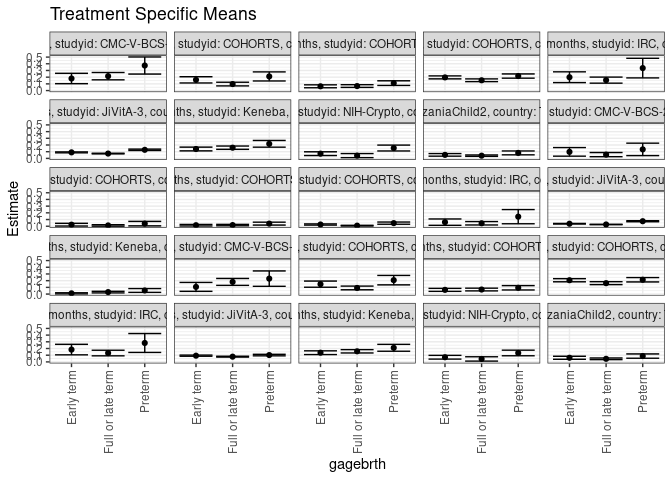

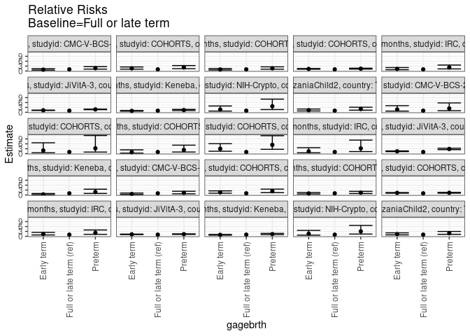

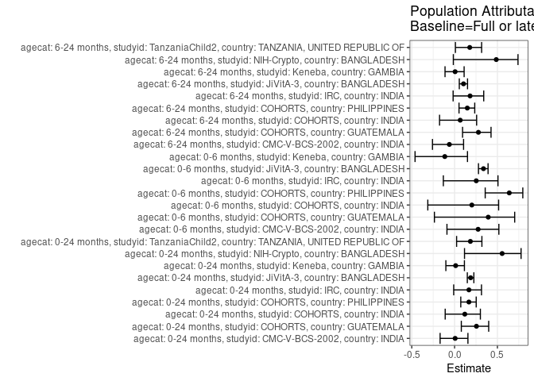

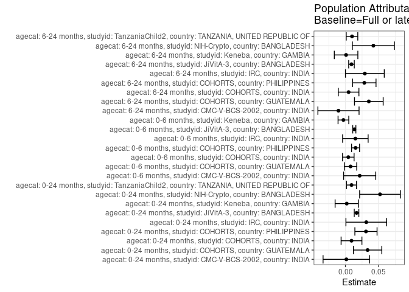

## Results Table

### Parameter: TSM

| agecat | studyid | country | intervention_level | baseline_level | estimate | ci_lower | ci_upper |
| --- | --- | --- | --- | --- | --- | --- | --- |
| 0-24 months | CMC-V-BCS-2002 | INDIA | Full or late term | NA | 0.2151205 | 0.1605110 | 0.2697299 |
| 0-24 months | CMC-V-BCS-2002 | INDIA | Preterm | NA | 0.3740099 | 0.2463678 | 0.5016519 |
| 0-24 months | CMC-V-BCS-2002 | INDIA | Early term | NA | 0.1800867 | 0.1029340 | 0.2572395 |
| 0-24 months | COHORTS | GUATEMALA | Full or late term | NA | 0.0972146 | 0.0698328 | 0.1245964 |
| 0-24 months | COHORTS | GUATEMALA | Preterm | NA | 0.2110419 | 0.1435271 | 0.2785567 |
| 0-24 months | COHORTS | GUATEMALA | Early term | NA | 0.1599931 | 0.1135145 | 0.2064717 |
| 0-24 months | COHORTS | INDIA | Full or late term | NA | 0.0674508 | 0.0473284 | 0.0875731 |
| 0-24 months | COHORTS | INDIA | Preterm | NA | 0.1111851 | 0.0764252 | 0.1459451 |
| 0-24 months | COHORTS | INDIA | Early term | NA | 0.0639208 | 0.0419539 | 0.0858878 |
| 0-24 months | COHORTS | PHILIPPINES | Full or late term | NA | 0.1536469 | 0.1331442 | 0.1741497 |
| 0-24 months | COHORTS | PHILIPPINES | Preterm | NA | 0.2170043 | 0.1855194 | 0.2484892 |
| 0-24 months | COHORTS | PHILIPPINES | Early term | NA | 0.1967064 | 0.1747095 | 0.2187032 |
| 0-24 months | IRC | INDIA | Full or late term | NA | 0.1558356 | 0.1107549 | 0.2009164 |
| 0-24 months | IRC | INDIA | Preterm | NA | 0.3357056 | 0.1892905 | 0.4821207 |
| 0-24 months | IRC | INDIA | Early term | NA | 0.1992948 | 0.1189136 | 0.2796760 |
| 0-24 months | JiVitA-3 | BANGLADESH | Full or late term | NA | 0.0722751 | 0.0675027 | 0.0770475 |
| 0-24 months | JiVitA-3 | BANGLADESH | Preterm | NA | 0.1281681 | 0.1180293 | 0.1383069 |
| 0-24 months | JiVitA-3 | BANGLADESH | Early term | NA | 0.0901731 | 0.0830967 | 0.0972495 |
| 0-24 months | Keneba | GAMBIA | Full or late term | NA | 0.1599747 | 0.1352430 | 0.1847063 |
| 0-24 months | Keneba | GAMBIA | Preterm | NA | 0.2177828 | 0.1678903 | 0.2676753 |
| 0-24 months | Keneba | GAMBIA | Early term | NA | 0.1403400 | 0.1125625 | 0.1681175 |
| 0-24 months | NIH-Crypto | BANGLADESH | Full or late term | NA | 0.0416667 | 0.0114301 | 0.0719033 |
| 0-24 months | NIH-Crypto | BANGLADESH | Preterm | NA | 0.1547170 | 0.1111476 | 0.1982864 |
| 0-24 months | NIH-Crypto | BANGLADESH | Early term | NA | 0.0707692 | 0.0428710 | 0.0986675 |
| 0-24 months | TanzaniaChild2 | TANZANIA, UNITED REPUBLIC OF | Full or late term | NA | 0.0405251 | 0.0301670 | 0.0508831 |
| 0-24 months | TanzaniaChild2 | TANZANIA, UNITED REPUBLIC OF | Preterm | NA | 0.0819071 | 0.0530399 | 0.1107743 |
| 0-24 months | TanzaniaChild2 | TANZANIA, UNITED REPUBLIC OF | Early term | NA | 0.0528170 | 0.0336032 | 0.0720308 |
| 0-6 months | CMC-V-BCS-2002 | INDIA | Full or late term | NA | 0.0566038 | 0.0254523 | 0.0877552 |
| 0-6 months | CMC-V-BCS-2002 | INDIA | Preterm | NA | 0.1346154 | 0.0417130 | 0.2275178 |
| 0-6 months | CMC-V-BCS-2002 | INDIA | Early term | NA | 0.0975610 | 0.0332453 | 0.1618766 |
| 0-6 months | COHORTS | GUATEMALA | Full or late term | NA | 0.0119048 | 0.0015255 | 0.0222840 |
| 0-6 months | COHORTS | GUATEMALA | Preterm | NA | 0.0387597 | 0.0054291 | 0.0720903 |
| 0-6 months | COHORTS | GUATEMALA | Early term | NA | 0.0231481 | 0.0030814 | 0.0432149 |
| 0-6 months | COHORTS | INDIA | Full or late term | NA | 0.0171821 | 0.0066207 | 0.0277436 |
| 0-6 months | COHORTS | INDIA | Preterm | NA | 0.0389610 | 0.0173428 | 0.0605792 |
| 0-6 months | COHORTS | INDIA | Early term | NA | 0.0152838 | 0.0040443 | 0.0265234 |
| 0-6 months | COHORTS | PHILIPPINES | Full or late term | NA | 0.0086276 | 0.0032794 | 0.0139758 |
| 0-6 months | COHORTS | PHILIPPINES | Preterm | NA | 0.0464554 | 0.0301487 | 0.0627621 |
| 0-6 months | COHORTS | PHILIPPINES | Early term | NA | 0.0257731 | 0.0168291 | 0.0347171 |
| 0-6 months | IRC | INDIA | Full or late term | NA | 0.0441767 | 0.0186207 | 0.0697327 |
| 0-6 months | IRC | INDIA | Preterm | NA | 0.1428571 | 0.0368927 | 0.2488215 |
| 0-6 months | IRC | INDIA | Early term | NA | 0.0612245 | 0.0136978 | 0.1087512 |
| 0-6 months | JiVitA-3 | BANGLADESH | Full or late term | NA | 0.0262139 | 0.0233868 | 0.0290409 |
| 0-6 months | JiVitA-3 | BANGLADESH | Preterm | NA | 0.0750139 | 0.0671944 | 0.0828333 |
| 0-6 months | JiVitA-3 | BANGLADESH | Early term | NA | 0.0372099 | 0.0325049 | 0.0419150 |
| 0-6 months | Keneba | GAMBIA | Full or late term | NA | 0.0295250 | 0.0176344 | 0.0414156 |
| 0-6 months | Keneba | GAMBIA | Preterm | NA | 0.0537190 | 0.0253038 | 0.0821343 |
| 0-6 months | Keneba | GAMBIA | Early term | NA | 0.0106383 | 0.0021688 | 0.0191078 |
| 6-24 months | CMC-V-BCS-2002 | INDIA | Full or late term | NA | 0.1813953 | 0.1298133 | 0.2329774 |
| 6-24 months | CMC-V-BCS-2002 | INDIA | Preterm | NA | 0.2307692 | 0.1160904 | 0.3454481 |
| 6-24 months | CMC-V-BCS-2002 | INDIA | Early term | NA | 0.1071429 | 0.0409059 | 0.1733798 |
| 6-24 months | COHORTS | GUATEMALA | Full or late term | NA | 0.0912849 | 0.0637859 | 0.1187839 |
| 6-24 months | COHORTS | GUATEMALA | Preterm | NA | 0.2077137 | 0.1372214 | 0.2782060 |
| 6-24 months | COHORTS | GUATEMALA | Early term | NA | 0.1480323 | 0.1018762 | 0.1941883 |
| 6-24 months | COHORTS | INDIA | Full or late term | NA | 0.0675969 | 0.0471307 | 0.0880630 |
| 6-24 months | COHORTS | INDIA | Preterm | NA | 0.0938013 | 0.0611705 | 0.1264321 |
| 6-24 months | COHORTS | INDIA | Early term | NA | 0.0628315 | 0.0404542 | 0.0852089 |
| 6-24 months | COHORTS | PHILIPPINES | Full or late term | NA | 0.1629318 | 0.1411473 | 0.1847162 |
| 6-24 months | COHORTS | PHILIPPINES | Preterm | NA | 0.2136790 | 0.1811445 | 0.2462134 |
| 6-24 months | COHORTS | PHILIPPINES | Early term | NA | 0.2066766 | 0.1832901 | 0.2300631 |
| 6-24 months | IRC | INDIA | Full or late term | NA | 0.1323481 | 0.0902288 | 0.1744674 |
| 6-24 months | IRC | INDIA | Preterm | NA | 0.2824816 | 0.1414981 | 0.4234650 |
| 6-24 months | IRC | INDIA | Early term | NA | 0.1836595 | 0.1051625 | 0.2621565 |
| 6-24 months | JiVitA-3 | BANGLADESH | Full or late term | NA | 0.0780919 | 0.0720178 | 0.0841660 |
| 6-24 months | JiVitA-3 | BANGLADESH | Preterm | NA | 0.1019647 | 0.0903501 | 0.1135792 |
| 6-24 months | JiVitA-3 | BANGLADESH | Early term | NA | 0.0928295 | 0.0843654 | 0.1012936 |
| 6-24 months | Keneba | GAMBIA | Full or late term | NA | 0.1580548 | 0.1330580 | 0.1830517 |
| 6-24 months | Keneba | GAMBIA | Preterm | NA | 0.2103983 | 0.1590394 | 0.2617572 |
| 6-24 months | Keneba | GAMBIA | Early term | NA | 0.1373378 | 0.1093119 | 0.1653638 |
| 6-24 months | NIH-Crypto | BANGLADESH | Full or late term | NA | 0.0443038 | 0.0121970 | 0.0764106 |
| 6-24 months | NIH-Crypto | BANGLADESH | Preterm | NA | 0.1333333 | 0.0915819 | 0.1750847 |
| 6-24 months | NIH-Crypto | BANGLADESH | Early term | NA | 0.0694006 | 0.0414057 | 0.0973955 |
| 6-24 months | TanzaniaChild2 | TANZANIA, UNITED REPUBLIC OF | Full or late term | NA | 0.0460218 | 0.0339482 | 0.0580954 |
| 6-24 months | TanzaniaChild2 | TANZANIA, UNITED REPUBLIC OF | Preterm | NA | 0.0869356 | 0.0549764 | 0.1188948 |
| 6-24 months | TanzaniaChild2 | TANZANIA, UNITED REPUBLIC OF | Early term | NA | 0.0616343 | 0.0391035 | 0.0841652 |

### Parameter: E(Y)

| agecat | studyid | country | intervention_level | baseline_level | estimate | ci_lower | ci_upper |
| --- | --- | --- | --- | --- | --- | --- | --- |
| 0-24 months | CMC-V-BCS-2002 | INDIA | NA | NA | 0.2165242 | 0.1733743 | 0.2596741 |
| 0-24 months | COHORTS | GUATEMALA | NA | NA | 0.1305419 | 0.1073553 | 0.1537285 |
| 0-24 months | COHORTS | INDIA | NA | NA | 0.0765864 | 0.0625045 | 0.0906684 |
| 0-24 months | COHORTS | PHILIPPINES | NA | NA | 0.1844982 | 0.1706594 | 0.1983369 |
| 0-24 months | IRC | INDIA | NA | NA | 0.1871795 | 0.1484181 | 0.2259409 |
| 0-24 months | JiVitA-3 | BANGLADESH | NA | NA | 0.0889695 | 0.0850028 | 0.0929362 |
| 0-24 months | Keneba | GAMBIA | NA | NA | 0.1619718 | 0.1444738 | 0.1794699 |
| 0-24 months | NIH-Crypto | BANGLADESH | NA | NA | 0.0936675 | 0.0729118 | 0.1144233 |
| 0-24 months | TanzaniaChild2 | TANZANIA, UNITED REPUBLIC OF | NA | NA | 0.0496894 | 0.0407166 | 0.0586623 |
| 0-6 months | CMC-V-BCS-2002 | INDIA | NA | NA | 0.0780347 | 0.0497312 | 0.1063382 |
| 0-6 months | COHORTS | GUATEMALA | NA | NA | 0.0196078 | 0.0097764 | 0.0294393 |
| 0-6 months | COHORTS | INDIA | NA | NA | 0.0215134 | 0.0137652 | 0.0292615 |
| 0-6 months | COHORTS | PHILIPPINES | NA | NA | 0.0238569 | 0.0184115 | 0.0293022 |
| 0-6 months | IRC | INDIA | NA | NA | 0.0591260 | 0.0356574 | 0.0825946 |
| 0-6 months | JiVitA-3 | BANGLADESH | NA | NA | 0.0395520 | 0.0369981 | 0.0421059 |
| 0-6 months | Keneba | GAMBIA | NA | NA | 0.0264984 | 0.0185889 | 0.0344079 |
| 6-24 months | CMC-V-BCS-2002 | INDIA | NA | NA | 0.1709402 | 0.1315009 | 0.2103795 |
| 6-24 months | COHORTS | GUATEMALA | NA | NA | 0.1264668 | 0.1029292 | 0.1500043 |
| 6-24 months | COHORTS | INDIA | NA | NA | 0.0723436 | 0.0584002 | 0.0862871 |
| 6-24 months | COHORTS | PHILIPPINES | NA | NA | 0.1913137 | 0.1767054 | 0.2059220 |
| 6-24 months | IRC | INDIA | NA | NA | 0.1615385 | 0.1249661 | 0.1981108 |
| 6-24 months | JiVitA-3 | BANGLADESH | NA | NA | 0.0871863 | 0.0825060 | 0.0918667 |
| 6-24 months | Keneba | GAMBIA | NA | NA | 0.1590214 | 0.1412900 | 0.1767528 |
| 6-24 months | NIH-Crypto | BANGLADESH | NA | NA | 0.0863014 | 0.0659171 | 0.1066856 |
| 6-24 months | TanzaniaChild2 | TANZANIA, UNITED REPUBLIC OF | NA | NA | 0.0559072 | 0.0455633 | 0.0662511 |

### Parameter: RR

| agecat | studyid | country | intervention_level | baseline_level | estimate | ci_lower | ci_upper |
| --- | --- | --- | --- | --- | --- | --- | --- |
| 0-24 months | CMC-V-BCS-2002 | INDIA | Full or late term | Full or late term | 1.0000000 | 1.0000000 | 1.000000 |
| 0-24 months | CMC-V-BCS-2002 | INDIA | Preterm | Full or late term | 1.7386065 | 1.1348037 | 2.663679 |
| 0-24 months | CMC-V-BCS-2002 | INDIA | Early term | Full or late term | 0.8371435 | 0.5086169 | 1.377872 |
| 0-24 months | COHORTS | GUATEMALA | Full or late term | Full or late term | 1.0000000 | 1.0000000 | 1.000000 |
| 0-24 months | COHORTS | GUATEMALA | Preterm | Full or late term | 2.1708873 | 1.4184936 | 3.322364 |
| 0-24 months | COHORTS | GUATEMALA | Early term | Full or late term | 1.6457723 | 1.0990085 | 2.464555 |
| 0-24 months | COHORTS | INDIA | Full or late term | Full or late term | 1.0000000 | 1.0000000 | 1.000000 |
| 0-24 months | COHORTS | INDIA | Preterm | Full or late term | 1.6483897 | 1.0717346 | 2.535318 |
| 0-24 months | COHORTS | INDIA | Early term | Full or late term | 0.9476662 | 0.6026417 | 1.490224 |
| 0-24 months | COHORTS | PHILIPPINES | Full or late term | Full or late term | 1.0000000 | 1.0000000 | 1.000000 |
| 0-24 months | COHORTS | PHILIPPINES | Preterm | Full or late term | 1.4123569 | 1.1609908 | 1.718146 |
| 0-24 months | COHORTS | PHILIPPINES | Early term | Full or late term | 1.2802492 | 1.0772319 | 1.521528 |
| 0-24 months | IRC | INDIA | Full or late term | Full or late term | 1.0000000 | 1.0000000 | 1.000000 |
| 0-24 months | IRC | INDIA | Preterm | Full or late term | 2.1542285 | 1.2753189 | 3.638855 |
| 0-24 months | IRC | INDIA | Early term | Full or late term | 1.2788782 | 0.7780066 | 2.102205 |
| 0-24 months | JiVitA-3 | BANGLADESH | Full or late term | Full or late term | 1.0000000 | 1.0000000 | 1.000000 |
| 0-24 months | JiVitA-3 | BANGLADESH | Preterm | Full or late term | 1.7733370 | 1.6039335 | 1.960632 |
| 0-24 months | JiVitA-3 | BANGLADESH | Early term | Full or late term | 1.2476368 | 1.1314378 | 1.375770 |
| 0-24 months | Keneba | GAMBIA | Full or late term | Full or late term | 1.0000000 | 1.0000000 | 1.000000 |
| 0-24 months | Keneba | GAMBIA | Preterm | Full or late term | 1.3613582 | 1.0331572 | 1.793818 |
| 0-24 months | Keneba | GAMBIA | Early term | Full or late term | 0.8772641 | 0.6829269 | 1.126903 |
| 0-24 months | NIH-Crypto | BANGLADESH | Full or late term | Full or late term | 1.0000000 | 1.0000000 | 1.000000 |
| 0-24 months | NIH-Crypto | BANGLADESH | Preterm | Full or late term | 3.7132075 | 1.7048770 | 8.087334 |
| 0-24 months | NIH-Crypto | BANGLADESH | Early term | Full or late term | 1.6984615 | 0.7436993 | 3.878949 |
| 0-24 months | TanzaniaChild2 | TANZANIA, UNITED REPUBLIC OF | Full or late term | Full or late term | 1.0000000 | 1.0000000 | 1.000000 |
| 0-24 months | TanzaniaChild2 | TANZANIA, UNITED REPUBLIC OF | Preterm | Full or late term | 2.0211475 | 1.3076282 | 3.124005 |
| 0-24 months | TanzaniaChild2 | TANZANIA, UNITED REPUBLIC OF | Early term | Full or late term | 1.3033175 | 0.8354617 | 2.033171 |
| 0-6 months | CMC-V-BCS-2002 | INDIA | Full or late term | Full or late term | 1.0000000 | 1.0000000 | 1.000000 |
| 0-6 months | CMC-V-BCS-2002 | INDIA | Preterm | Full or late term | 2.3782051 | 0.9837792 | 5.749115 |
| 0-6 months | CMC-V-BCS-2002 | INDIA | Early term | Full or late term | 1.7235772 | 0.7302577 | 4.068041 |
| 0-6 months | COHORTS | GUATEMALA | Full or late term | Full or late term | 1.0000000 | 1.0000000 | 1.000000 |
| 0-6 months | COHORTS | GUATEMALA | Preterm | Full or late term | 3.2558140 | 0.9568134 | 11.078779 |
| 0-6 months | COHORTS | GUATEMALA | Early term | Full or late term | 1.9444444 | 0.5686405 | 6.648953 |
| 0-6 months | COHORTS | INDIA | Full or late term | Full or late term | 1.0000000 | 1.0000000 | 1.000000 |
| 0-6 months | COHORTS | INDIA | Preterm | Full or late term | 2.2675325 | 0.9906640 | 5.190159 |
| 0-6 months | COHORTS | INDIA | Early term | Full or late term | 0.8895197 | 0.3411203 | 2.319549 |
| 0-6 months | COHORTS | PHILIPPINES | Full or late term | Full or late term | 1.0000000 | 1.0000000 | 1.000000 |
| 0-6 months | COHORTS | PHILIPPINES | Preterm | Full or late term | 5.3845373 | 2.6398618 | 10.982864 |
| 0-6 months | COHORTS | PHILIPPINES | Early term | Full or late term | 2.9872938 | 1.4674847 | 6.081102 |
| 0-6 months | IRC | INDIA | Full or late term | Full or late term | 1.0000000 | 1.0000000 | 1.000000 |
| 0-6 months | IRC | INDIA | Preterm | Full or late term | 3.2337662 | 1.2623595 | 8.283888 |
| 0-6 months | IRC | INDIA | Early term | Full or late term | 1.3858998 | 0.5263615 | 3.649048 |
| 0-6 months | JiVitA-3 | BANGLADESH | Full or late term | Full or late term | 1.0000000 | 1.0000000 | 1.000000 |
| 0-6 months | JiVitA-3 | BANGLADESH | Preterm | Full or late term | 2.8616092 | 2.4596263 | 3.329289 |
| 0-6 months | JiVitA-3 | BANGLADESH | Early term | Full or late term | 1.4194742 | 1.2124851 | 1.661799 |
| 0-6 months | Keneba | GAMBIA | Full or late term | Full or late term | 1.0000000 | 1.0000000 | 1.000000 |
| 0-6 months | Keneba | GAMBIA | Preterm | Full or late term | 1.8194395 | 0.9358545 | 3.537259 |
| 0-6 months | Keneba | GAMBIA | Early term | Full or late term | 0.3603145 | 0.1476399 | 0.879346 |
| 6-24 months | CMC-V-BCS-2002 | INDIA | Full or late term | Full or late term | 1.0000000 | 1.0000000 | 1.000000 |
| 6-24 months | CMC-V-BCS-2002 | INDIA | Preterm | Full or late term | 1.2721893 | 0.7176235 | 2.255313 |
| 6-24 months | CMC-V-BCS-2002 | INDIA | Early term | Full or late term | 0.5906593 | 0.2990956 | 1.166445 |
| 6-24 months | COHORTS | GUATEMALA | Full or late term | Full or late term | 1.0000000 | 1.0000000 | 1.000000 |
| 6-24 months | COHORTS | GUATEMALA | Preterm | Full or late term | 2.2754448 | 1.4460391 | 3.580573 |
| 6-24 months | COHORTS | GUATEMALA | Early term | Full or late term | 1.6216516 | 1.0527609 | 2.497959 |
| 6-24 months | COHORTS | INDIA | Full or late term | Full or late term | 1.0000000 | 1.0000000 | 1.000000 |
| 6-24 months | COHORTS | INDIA | Preterm | Full or late term | 1.3876571 | 0.8774395 | 2.194558 |
| 6-24 months | COHORTS | INDIA | Early term | Full or late term | 0.9295037 | 0.5835606 | 1.480527 |
| 6-24 months | COHORTS | PHILIPPINES | Full or late term | Full or late term | 1.0000000 | 1.0000000 | 1.000000 |
| 6-24 months | COHORTS | PHILIPPINES | Preterm | Full or late term | 1.3114628 | 1.0725178 | 1.603642 |
| 6-24 months | COHORTS | PHILIPPINES | Early term | Full or late term | 1.2684854 | 1.0662730 | 1.509046 |
| 6-24 months | IRC | INDIA | Full or late term | Full or late term | 1.0000000 | 1.0000000 | 1.000000 |
| 6-24 months | IRC | INDIA | Preterm | Full or late term | 2.1343838 | 1.1805073 | 3.859014 |
| 6-24 months | IRC | INDIA | Early term | Full or late term | 1.3877006 | 0.8141685 | 2.365251 |
| 6-24 months | JiVitA-3 | BANGLADESH | Full or late term | Full or late term | 1.0000000 | 1.0000000 | 1.000000 |
| 6-24 months | JiVitA-3 | BANGLADESH | Preterm | Full or late term | 1.3057006 | 1.1411597 | 1.493966 |
| 6-24 months | JiVitA-3 | BANGLADESH | Early term | Full or late term | 1.1887212 | 1.0567092 | 1.337225 |
| 6-24 months | Keneba | GAMBIA | Full or late term | Full or late term | 1.0000000 | 1.0000000 | 1.000000 |
| 6-24 months | Keneba | GAMBIA | Preterm | Full or late term | 1.3311727 | 0.9956895 | 1.779692 |
| 6-24 months | Keneba | GAMBIA | Early term | Full or late term | 0.8689251 | 0.6719525 | 1.123637 |
| 6-24 months | NIH-Crypto | BANGLADESH | Full or late term | Full or late term | 1.0000000 | 1.0000000 | 1.000000 |
| 6-24 months | NIH-Crypto | BANGLADESH | Preterm | Full or late term | 3.0095238 | 1.3666005 | 6.627565 |
| 6-24 months | NIH-Crypto | BANGLADESH | Early term | Full or late term | 1.5664714 | 0.6834694 | 3.590260 |
| 6-24 months | TanzaniaChild2 | TANZANIA, UNITED REPUBLIC OF | Full or late term | Full or late term | 1.0000000 | 1.0000000 | 1.000000 |
| 6-24 months | TanzaniaChild2 | TANZANIA, UNITED REPUBLIC OF | Preterm | Full or late term | 1.8890089 | 1.2025121 | 2.967417 |
| 6-24 months | TanzaniaChild2 | TANZANIA, UNITED REPUBLIC OF | Early term | Full or late term | 1.3392422 | 0.8539792 | 2.100250 |

### Parameter: PAR

| agecat | studyid | country | intervention_level | baseline_level | estimate | ci_lower | ci_upper |
| --- | --- | --- | --- | --- | --- | --- | --- |
| 0-24 months | CMC-V-BCS-2002 | INDIA | Full or late term | NA | 0.0014037 | -0.0336172 | 0.0364247 |
| 0-24 months | COHORTS | GUATEMALA | Full or late term | NA | 0.0333273 | 0.0119834 | 0.0546712 |
| 0-24 months | COHORTS | INDIA | Full or late term | NA | 0.0091357 | -0.0065089 | 0.0247803 |
| 0-24 months | COHORTS | PHILIPPINES | Full or late term | NA | 0.0308512 | 0.0141734 | 0.0475291 |
| 0-24 months | IRC | INDIA | Full or late term | NA | 0.0313438 | 0.0007454 | 0.0619423 |
| 0-24 months | JiVitA-3 | BANGLADESH | Full or late term | NA | 0.0166944 | 0.0132450 | 0.0201437 |
| 0-24 months | Keneba | GAMBIA | Full or late term | NA | 0.0019972 | -0.0155166 | 0.0195110 |
| 0-24 months | NIH-Crypto | BANGLADESH | Full or late term | NA | 0.0520009 | 0.0213449 | 0.0826569 |
| 0-24 months | TanzaniaChild2 | TANZANIA, UNITED REPUBLIC OF | Full or late term | NA | 0.0091644 | 0.0016891 | 0.0166396 |
| 0-6 months | CMC-V-BCS-2002 | INDIA | Full or late term | NA | 0.0214309 | -0.0027005 | 0.0455623 |
| 0-6 months | COHORTS | GUATEMALA | Full or late term | NA | 0.0077031 | -0.0015757 | 0.0169818 |
| 0-6 months | COHORTS | INDIA | Full or late term | NA | 0.0043312 | -0.0043440 | 0.0130064 |
| 0-6 months | COHORTS | PHILIPPINES | Full or late term | NA | 0.0152293 | 0.0091928 | 0.0212658 |
| 0-6 months | IRC | INDIA | Full or late term | NA | 0.0149493 | -0.0042281 | 0.0341266 |
| 0-6 months | JiVitA-3 | BANGLADESH | Full or late term | NA | 0.0133381 | 0.0109912 | 0.0156851 |
| 0-6 months | Keneba | GAMBIA | Full or late term | NA | -0.0030266 | -0.0110869 | 0.0050337 |
| 6-24 months | CMC-V-BCS-2002 | INDIA | Full or late term | NA | -0.0104552 | -0.0413843 | 0.0204739 |
| 6-24 months | COHORTS | GUATEMALA | Full or late term | NA | 0.0351819 | 0.0136369 | 0.0567269 |
| 6-24 months | COHORTS | INDIA | Full or late term | NA | 0.0047468 | -0.0107794 | 0.0202729 |
| 6-24 months | COHORTS | PHILIPPINES | Full or late term | NA | 0.0283819 | 0.0107889 | 0.0459750 |
| 6-24 months | IRC | INDIA | Full or late term | NA | 0.0291904 | 0.0000147 | 0.0583661 |
| 6-24 months | JiVitA-3 | BANGLADESH | Full or late term | NA | 0.0090944 | 0.0048982 | 0.0132906 |
| 6-24 months | Keneba | GAMBIA | Full or late term | NA | 0.0009666 | -0.0167254 | 0.0186585 |
| 6-24 months | NIH-Crypto | BANGLADESH | Full or late term | NA | 0.0419976 | 0.0103726 | 0.0736225 |
| 6-24 months | TanzaniaChild2 | TANZANIA, UNITED REPUBLIC OF | Full or late term | NA | 0.0098854 | 0.0012043 | 0.0185664 |

### Parameter: PAF

| agecat | studyid | country | intervention_level | baseline_level | estimate | ci_lower | ci_upper |
| --- | --- | --- | --- | --- | --- | --- | --- |
| 0-24 months | CMC-V-BCS-2002 | INDIA | Full or late term | NA | 0.0064831 | -0.1691210 | 0.1557111 |
| 0-24 months | COHORTS | GUATEMALA | Full or late term | NA | 0.2552996 | 0.0785899 | 0.3981196 |
| 0-24 months | COHORTS | INDIA | Full or late term | NA | 0.1192858 | -0.1097097 | 0.3010266 |
| 0-24 months | COHORTS | PHILIPPINES | Full or late term | NA | 0.1672171 | 0.0722571 | 0.2524574 |
| 0-24 months | IRC | INDIA | Full or late term | NA | 0.1674534 | -0.0104004 | 0.3140008 |
| 0-24 months | JiVitA-3 | BANGLADESH | Full or late term | NA | 0.1876417 | 0.1485467 | 0.2249416 |
| 0-24 months | Keneba | GAMBIA | Full or late term | NA | 0.0123304 | -0.1019453 | 0.1147552 |
| 0-24 months | NIH-Crypto | BANGLADESH | Full or late term | NA | 0.5551643 | 0.1158430 | 0.7761950 |
| 0-24 months | TanzaniaChild2 | TANZANIA, UNITED REPUBLIC OF | Full or late term | NA | 0.1844333 | 0.0235222 | 0.3188283 |
| 0-6 months | CMC-V-BCS-2002 | INDIA | Full or late term | NA | 0.2746331 | -0.0891296 | 0.5169013 |
| 0-6 months | COHORTS | GUATEMALA | Full or late term | NA | 0.3928571 | -0.2355181 | 0.7016455 |
| 0-6 months | COHORTS | INDIA | Full or late term | NA | 0.2013272 | -0.3127887 | 0.5141044 |
| 0-6 months | COHORTS | PHILIPPINES | Full or late term | NA | 0.6383613 | 0.3574589 | 0.7964604 |
| 0-6 months | IRC | INDIA | Full or late term | NA | 0.2528374 | -0.1313107 | 0.5065442 |
| 0-6 months | JiVitA-3 | BANGLADESH | Full or late term | NA | 0.3372302 | 0.2789072 | 0.3908359 |
| 0-6 months | Keneba | GAMBIA | Full or late term | NA | -0.1142185 | -0.4616076 | 0.1506046 |
| 6-24 months | CMC-V-BCS-2002 | INDIA | Full or late term | NA | -0.0611628 | -0.2580714 | 0.1049264 |
| 6-24 months | COHORTS | GUATEMALA | Full or late term | NA | 0.2781907 | 0.0931088 | 0.4255004 |
| 6-24 months | COHORTS | INDIA | Full or late term | NA | 0.0656142 | -0.1755080 | 0.2572769 |
| 6-24 months | COHORTS | PHILIPPINES | Full or late term | NA | 0.1483529 | 0.0516559 | 0.2351903 |
| 6-24 months | IRC | INDIA | Full or late term | NA | 0.1807024 | -0.0171986 | 0.3401008 |
| 6-24 months | JiVitA-3 | BANGLADESH | Full or late term | NA | 0.1043101 | 0.0549148 | 0.1511239 |
| 6-24 months | Keneba | GAMBIA | Full or late term | NA | 0.0060782 | -0.1116421 | 0.1113321 |
| 6-24 months | NIH-Crypto | BANGLADESH | Full or late term | NA | 0.4866385 | -0.0147040 | 0.7402790 |
| 6-24 months | TanzaniaChild2 | TANZANIA, UNITED REPUBLIC OF | Full or late term | NA | 0.1768179 | 0.0098505 | 0.3156298 |